# Kids Welcome!

## Predicting child friendliness of restaurant & food businesses from Yelp data

Summary presentation of key findings

Timm Suess, 2015-11-13

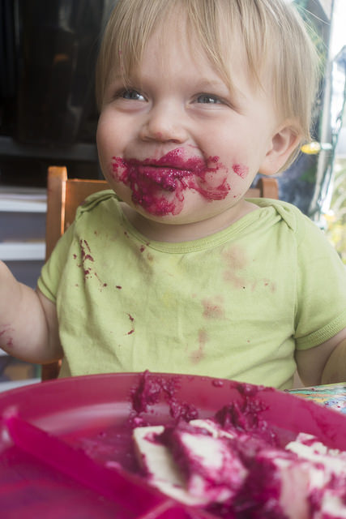

### Research focus and data preparation

**Research question**

How well can a “good for kids” rating of restaurant and food businesses be predicted from business features such as Yelp category, service attributes, city and key words in the business's name?

**Data Source**

[Yelp Dataset Challenge 6](http://www.yelp.com/dataset_challenge)

**Application**

- Parent-centric recommendation engines
- Restauration market research
- Review fraud detection

**Preprocessing**

- Extraction of all businesses identificaton, evaluation, categories, attributes, location
- Outcome variable: attribute “good for kids” (binary)
- Filtering (no NA in outcome, category “Restaurant”, “Food”)
- k-means clustering of GPS coordinates
- Inclusion of top 300 words in business names
- Creation of dummy variables

### Machine-learning approach

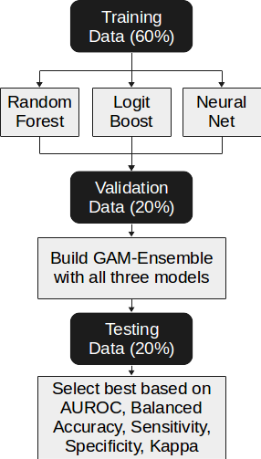

**Model building**

- Impute NAs with variable median
- Train three individual classifiers and one ensemble
- Validate and test
- select against multiple metrics

**Outcome variable is skewed**

More than 80% of all “good for kids” entries are positive:

|  | Not good for kids | Good for kids | Total |
| --- | --- | --- | --- |
| n | 3667 | 16424 | 20091 |
| % Total | 18.3% | 81.7% | 100% |

### Results: Random Forest as best model

**Key Metrics**

|  | RF | LB | NN | GAM |
| --- | --- | --- | --- | --- |
| AUROC | 0.91 | 0.87 | 0.83 | 0.56 |
| Balanced Accuracy | 0.75 | 0.71 | 0.72 | 0.53 |
| Sensitivity | 0.97 | 0.97 | 0.92 | 0.90 |
| Specificity | 0.54 | 0.46 | 0.53 | 0.15 |
| Kappa | 0.57 | 0.50 | 0.46 | 0.06 |

RF=Random Forest, LB=LogitBoost, NN=Neural Net, GAM=General Additive Model

Random Forest emerges as clear winner. GAM shows surprisingly low performance, despite being the ensemble model.

**ROC Curves**

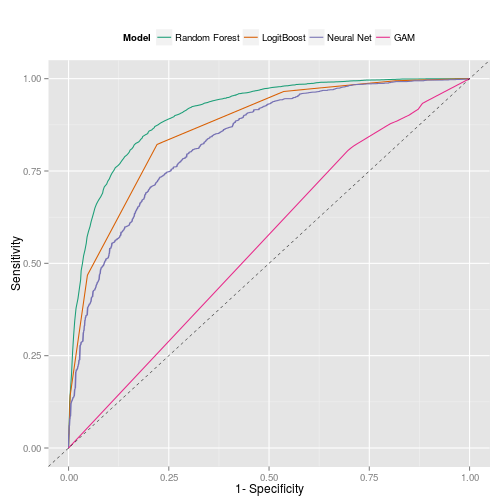

(GAM curve shows performance against testing data, others against validation data)

### Interpretation

**How well can child-friendliness be predicted?**

- Overall, RF predicts child-friendliness fairly well (good AUROC, Kappa, Accuacy).
- Excellent sensitivity, but poor specificity
- Solid basis for a (positive) recommendation engine

**Possible Improvements**

- Get more data on child-unfriendly venues (e.g. from review texts)
- Improve imputation algorithm
- Use expert knowledge to discover hidden variables
- Include additional variables (e.g. opening times)
- Use other algorithms (SVM, deep learning)